# Week 6 Analytical Assigment

M. Onimus

04/16/2020

# R Set up

Before getting started, I have loaded in a few packages to help us with the analysis.

- `tidyverse`: A collection of r packages used to make data import, manipulation, and analysis easier.
- `here`: A package that makes it easier to navigate around the folder structure.
- `haven`: A package with a set of functions for reading in SAS files.
- `rstatix`: A package to quickly calculate ttest between variables
- `kableExtra`: A package for printing pretty tables to html.
- `table1`: A package that allows for creation of table 1’s with relative ease

# From the Assignment

For the assignment you will use the data set health_500, which has the following variables:

- Subject: Unique observation identifier
- Treatment: 1=received the treatment; 0=did not receive the treatment
- disease_burden: general score of disease states at baseline - higher scores indicate higher illness burden
- SEX: 1=patient was male; 0=patient was female

# Assignment Start

## Read the data in

In order to read the data into R, we will need to use the `haven` package.

```r
nonParam <- read_sas(here("data/health_500.sas7bdat")) %>%
  mutate(treatment = as.factor(treatment),
         treatment = relevel(treatment, ref = '0'),
         SEX = as.factor(SEX),
         SEX = relevel(SEX, ref = '1')
         )
```

This data set contains 500 rows with 4 variables, as described in the data overview.

## Question 1

Run the following code to generate some descriptive statistics for disease_burden by treatment. (The maxdec=2 command limits the number of decimals places to 2. This can make the output easier to read).

```r
descStats <- nonParam %>%
  group_by(treatment) %>%
  summarise(count = n(),
            mean = mean(disease_burden),
            std = sd(disease_burden),
            se = std/sqrt(count),
            median = median(disease_burden),
            min = min(disease_burden),
            max = max(disease_burden),
            quantite = quantile(disease_burden, 0.75) - quantile(disease_burden, 0.25))
kable(descStats, digits = 2) %>%
  kable_styling()
```

| treatment | count | mean | std | se | median | min | max | quantite |
| --- | --- | --- | --- | --- | --- | --- | --- | --- |
| 0 | 338 | 1.59 | 2.98 | 0.16 | 0.99 | 0.18 | 36.52 | 1.09 |
| 1 | 162 | 1.52 | 1.27 | 0.10 | 1.21 | 0.22 | 7.83 | 1.21 |

Are there any indications in the table of descriptive statistics that suggest the data might not be normally distributed?

Yes, the number one indicator to me is the max of the data. We can see that the means and standard deviations are relatively small but the max for each treatment group, 0 and 1, are 36.52 and 7.83, respectively. These larger numbers indicate they may be some skewness to the data.

## Question 2

First, we will make a couple plots to take a look at the data, I tend to avoid histograms as they are very subject to bin width algorithms. I usually display both a density plot and a violin plot.

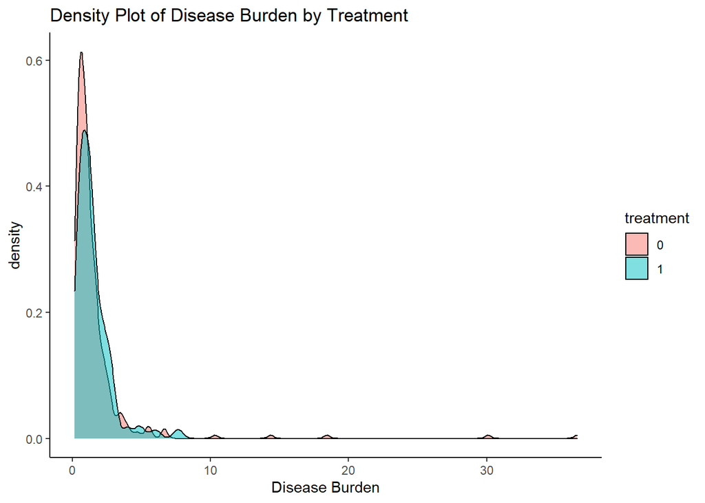

```r
ggplot(nonParam, aes(x = disease_burden, fill = treatment)) +
  geom_density(alpha = 0.5) +
  theme_classic() +
  labs(
    title = "Density Plot of Disease Burden by Treatment",
    x = "Disease Burden"
  )
```

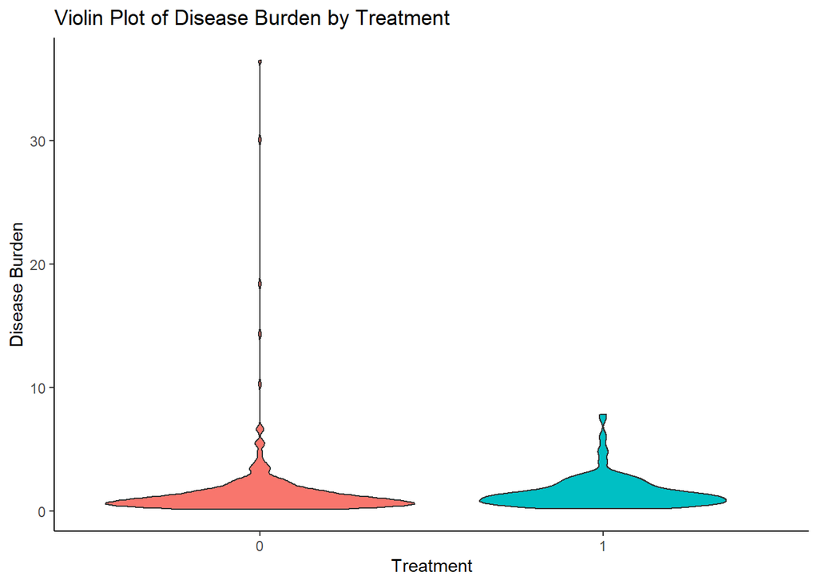

```r
ggplot(nonParam, aes(x = treatment, y = disease_burden, fill = treatment)) +
  geom_violin() +
  theme_classic() +
  theme(legend.position = 'none') +
  labs(
    title = "Violin Plot of Disease Burden by Treatment",
    x = "Treatment",
    y = "Disease Burden"
  )
```

Of course we will need to take a look at the qq plot as well

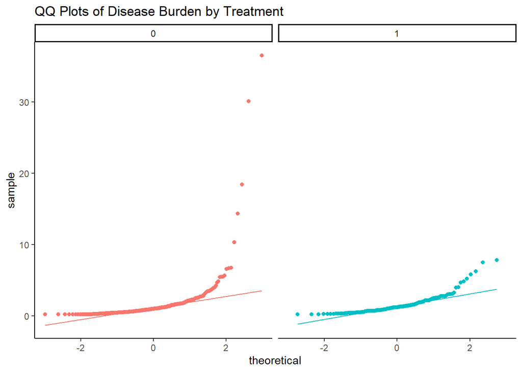

```r
ggplot(nonParam, aes(sample = disease_burden, color = treatment)) +
  stat_qq() +
  stat_qq_line() +
  facet_wrap(~treatment) +
  theme_classic() +
  theme(legend.position = 'none') +
  labs(
    title = "QQ Plots of Disease Burden by Treatment"
  )
```

Finally, we will conduct the Shapiro-Wilk test on both output groups.

```r
treat0 <- nonParam %>% filter(treatment == 0) %>% pull(disease_burden)
treat1 <- nonParam %>% filter(treatment == 1) %>% pull(disease_burden)

shap0 <- shapiro.test(treat0)
shap0
```

```
##
##  Shapiro-Wilk normality test
##
## data:  treat0
## W = 0.32936, p-value < 2.2e-16
```

```r
shap1 <- shapiro.test(treat1)
shap1
```

```
##
##  Shapiro-Wilk normality test
##
## data:  treat1
## W = 0.77561, p-value = 1.782e-14
```

Looking at the test for normality, is the variable disease_burden normally distributed? Interpret the Shapiro-Wilk test in the “Tests for Normality” output for both the treatment and control groups.

The Shapiro-Wilk test resulted in a p-value of 2.7378424^{-33} for the treatment 0 group and a p-value of 1.7824701^{-14} for the treatment 1 group. Both of these tests are statistically significant indicating the distribution of the data is not normal.

What other parts of the output of the PROC UNIVARIATE indicate that the data are not normally distributed?

All of the plots created indicate the data not normal. The distribution plot shows extreme tailing at the disease burden increases in both treatment groups. The violin plot shows a similar distribution with a large grouping of values at the lower disease burden values and quite a long tail as the disease burden increases. Finally, both qq plots diverge rather significantly from the qq line.

## Question 3

Run PROC SGPLOT and look at the boxplot it produces. What indication does the boxplot provide that the data might not me normally distributed?

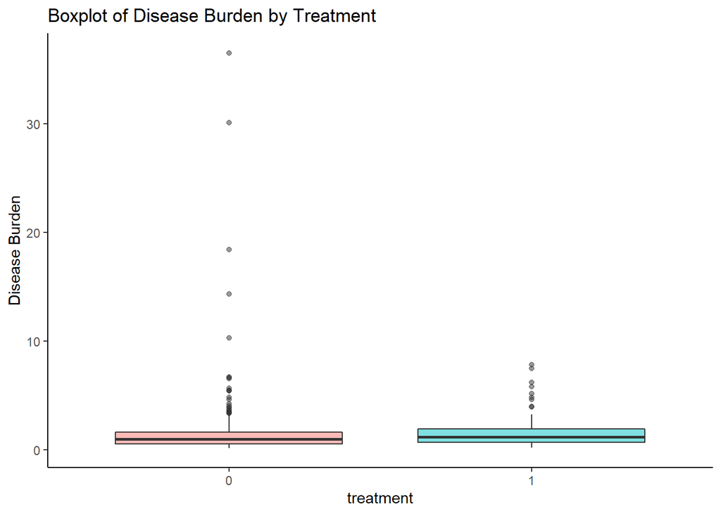

```r
ggplot(nonParam, aes(x = treatment, y = disease_burden, fill = treatment)) +
  geom_boxplot(alpha = 0.5) +
  theme_classic() +
  theme(legend.position = 'none') +
  labs(
    title = "Boxplot of Disease Burden by Treatment",
    y = "Disease Burden"
  )
```

(A personal note, I do prefer the violin plot to the box plot but understand the need to look at both.)

Similar to the other plots produced, there is noticeable tailing about the IQR of the plot. This is signified by the single points (outliers) not attached to whiskers of the plot.

## Question 4

Run the PROC NPAR1WAY code below.

```r
wilcoxon <- wilcox.test(disease_burden~treatment, data = nonParam)

wilcoxon
```

```
##
##  Wilcoxon rank sum test with continuity correction
##
## data:  disease_burden by treatment
## W = 23902, p-value = 0.0215
## alternative hypothesis: true location shift is not equal to 0
```

Looking at the Wilcoxon Scores (Rank Sums) table, how do you interpret the “Sum of Scores” and “Expected under H0”?

How do you interpret the “Mean Score” in the Wilcoxon Scores (Rank Sums) table?

According to the Wilcoxon Two-Sample Test and the Kruskal-Wallis Test, what do you conclude about whether disease burdens differ between the treatment and control groups?

According to both tests, the differences between the treatment and the control groups are statistically different with a p-value of 0.0215025 from the R version of the Wilcoxon test. The Wilcoxon version in R seems to align better with the KW test in SAS. There is quite an extensive note regarding the Wilcoxon test in R as there is not a unanimous definition of the test.

## Questions 5-6

Run the PROC TTEST code below. As you know, an independent samples t-test compares the means between two groups and assumes the outcome variable is normally distributed. The analyses in the NPAR1WAY procedure are the non-parametric equivalents of the test.

```r
ttest <- tidy(t.test(treat0, treat1))

ttest
```

```
## # A tibble: 1 x 10
##   estimate estimate1 estimate2 statistic p.value parameter conf.low conf.high
##      <dbl>     <dbl>     <dbl>     <dbl>   <dbl>     <dbl>    <dbl>     <dbl>
## 1   0.0678      1.59      1.52     0.357   0.721      493.   -0.306     0.441
## # ... with 2 more variables: method <chr>, alternative <chr>
```

What would you conclude about the mean differences in disease_burden based on the t-test?

The mean difference between the disease burden of the treatment groups is ~0.0678 corresponding to a p-value of 0.721405. The results indicate the difference is not statistically significant.

Based on the Wilcoxon test and the t-test, what would you say if someone asked you if disease burden differed between the treatment and control group?

Based on the non-normal distribution of data (see plots and Shapiro tests), a nonparametric test, Wilcoxon, will be used to assess the performance of the treatment options. The resulting Wilcoxon test showed the treatment differences were significant with a resulting p-value of 0.0215. In the event we assumed the data was normally distrubted and conducted a t-test, we would have arrived at a different conclusion. The t-test would have resulted in the difference not being statistically significant with a p-value of 0.72.